# R Notebook

# Final project Data Projects & Hackathon 2

# Exploring Mountaineering Success in the Himalayas: An Analysis of Recent Expeditions (2000–2025)

Dataset: https://github.com/rfordatascience/tidytuesday/tree/main/data/2025/2025-01-21

## Introduction and problem setting

The main objective is to explore what factors influence the outcome of an expedition. Some key questions:

- Does the use of supplementary oxygen reduce the duration of expeditions?
- Which features help expeditions reach the summit?
- Are autumn expeditions more likely to fail than spring expeditions?
- Does the use of supplementary oxygen increase the probability of success?
- Are expeditions hosted by Nepal or China more likely to succeed?

These questions are particularly relevant given the rich structure of the dataset.

Understanding the role of **oxygen usage** can help assess both its practical value and potential risks in high-altitude climbing. Analyzing **altitude** and **duration** relationships provides insight into how physical challenges scale with mountain difficulty. Seasonal variation is a classic factor in expedition planning, and quantifying its impact on success rates can inform safer scheduling. Finally, exploring **leadership origin** may reflect differences in strategy, experience, or logistical capacity across countries, revealing potential cultural or regional patterns in expedition outcomes.

These questions are not only statistically approachable through regression models, but also contextually meaningful for both mountaineering professionals and enthusiasts.

## Import data

```r
library(tidyverse)
```

```
G2;H2;Avvertimentoh: il pacchetto ‘ggplot2’ è stato creato con R versione 4.4.3g
```

```r
library(foreign)
library(httr)
library(zip)
library(ggcorrplot)
library(formattable)
library(VIM)
library(tidymodels)
library(glmnet)
library(infer)
```

```r
################################################################################
### Cleaning data from the Himalayan Database ##################################
################################################################################


Sys.setlocale("LC_ALL", "C")  # resolve encoding problem
```

```
[1] "C"
```

```r
# Step 1: Setup URL
url <- "https://www.himalayandatabase.com/downloads/Himalayan%20Database.zip"
zip_file <- tempfile(fileext = ".zip")
extracted_dir <- tempfile()

# Step 2: download ZIP and exctract
GET(url, write_disk(zip_file, overwrite = TRUE))
```

```
Response [https://www.himalayandatabase.com/downloads/Himalayan%20Database.zip]
  Date: 2025-05-23 09:48
  Status: 200
  Content-Type: application/zip
  Size: 38.3 MB
<ON DISK>  C:\Users\ms\AppData\Local\Temp\RtmpI5vyiJ\file3d646b284fa.zip
```

```r
unzip(zip_file, exdir = extracted_dir)

dbf_file_peaks <- file.path(extracted_dir, "Himalayan Database", "HIMDATA", "peaks.DBF")
dbf_file_exped <- file.path(extracted_dir, "Himalayan Database", "HIMDATA", "exped.DBF")

# Step 5: read DBF and ignore warnings (already verified it)
peaks_data <- suppressWarnings(read.dbf(dbf_file_peaks, as.is = TRUE))
exped_data <- suppressWarnings(read.dbf(dbf_file_exped, as.is = TRUE))

# Step 6: convert into Tibble
peaks_temp <- as_tibble(peaks_data)
exped_temp <- as_tibble(exped_data)

unlink(c(zip_file, extracted_dir), recursive = TRUE)
```

```r
###_____________________________________________________________________________
### Add columns that recode some variables that are integers into character
### strings that describe their subject in the peaks dataset
###_____________________________________________________________________________

peaks_tidy <- peaks_temp |>
  dplyr::mutate(HIMAL_FACTOR = case_when(
    HIMAL == 0  ~ "Unclassified",
    HIMAL == 1  ~ "Annapurna",
    HIMAL == 2  ~ "Api/Byas Risi/Guras",
    HIMAL == 3  ~ "Damodar",
    HIMAL == 4  ~ "Dhaulagiri",
    HIMAL == 5  ~ "Ganesh/Shringi",
    HIMAL == 6  ~ "Janak/Ohmi Kangri",
    HIMAL == 7  ~ "Jongsang",
    HIMAL == 8  ~ "Jugal",
    HIMAL == 9  ~ "Kangchenjunga/Simhalila",
    HIMAL == 10 ~ "Kanjiroba",
    HIMAL == 11 ~ "Kanti/Palchung",
    HIMAL == 12 ~ "Khumbu",
    HIMAL == 13 ~ "Langtang",
    HIMAL == 14 ~ "Makalu",
    HIMAL == 15 ~ "Manaslu/Mansiri",
    HIMAL == 16 ~ "Mukut/Mustang",
    HIMAL == 17 ~ "Nalakankar/Chandi/Changla",
    HIMAL == 18 ~ "Peri",
    HIMAL == 19 ~ "Rolwaling",
    HIMAL == 20 ~ "Saipal",
    TRUE ~ "Unknown" # Default case if a value doesn't match
  ),
  .after = HIMAL
  ) |>
  mutate(REGION_FACTOR = case_when(
    REGION == 0 ~ "Unclassified",
    REGION == 1 ~ "Kangchenjunga-Janak",
    REGION == 2 ~ "Khumbu-Rolwaling-Makalu",
    REGION == 3 ~ "Langtang-Jugal",
    REGION == 4 ~ "Manaslu-Ganesh",
    REGION == 5 ~ "Annapurna-Damodar-Peri",
    REGION == 6 ~ "Dhaulagiri-Mukut",
    REGION == 7 ~ "Kanjiroba-Far West",
    TRUE        ~ "Unknown" # Default case if a value doesn't match
  ),
  .after = REGION
  ) |>
  mutate(PHOST_FACTOR = case_when(
    PHOST == 0 ~ "Unclassified",
    PHOST == 1 ~ "Nepal only",
    PHOST == 2 ~ "China only",
    PHOST == 3 ~ "India only",
    PHOST == 4 ~ "Nepal & China",
    PHOST == 5 ~ "Nepal & India",
    PHOST == 6 ~ "Nepal, China & India",
    TRUE       ~ "Unknown" # Default case if a value doesn't match
  ),
  .after = PHOST
  ) |>
  mutate(PSTATUS_FACTOR = case_when(
    PSTATUS == 0 ~ "Unknown",
    PSTATUS == 1 ~ "Unclimbed",
    PSTATUS == 2 ~ "Climbed",
    TRUE         ~ "Invalid" # Default case if a value doesn't match
  ),
  .after = PSTATUS
  ) |>
  mutate(across(c(HIMAL_FACTOR, PHOST_FACTOR, PSTATUS_FACTOR), ~ factor(.)))
```

```r
exped_tidy <- exped_temp |>
  dplyr::mutate(YEAR = as.numeric(trimws(YEAR))) |>
  dplyr::filter(YEAR >= 2000) |>
  dplyr::mutate(SEASON_FACTOR = case_when(
    SEASON == 0 ~ "Unknown",
    SEASON == 1 ~ "Spring",
    SEASON == 2 ~ "Summer",
    SEASON == 3 ~ "Autumn",
    SEASON == 4 ~ "Winter",
    TRUE ~ NA_character_
  ), .after = SEASON) |>
  dplyr::mutate(HOST_FACTOR = case_when(
    HOST == 0 ~ "Unknown",
    HOST == 1 ~ "Nepal",
    HOST == 2 ~ "China",
    HOST == 3 ~ "India",
    TRUE ~ NA_character_
  ), .after = HOST) |>
  dplyr::mutate(TERMREASON_FACTOR = case_when(
    TERMREASON == 0 ~ "Unknown",
    TERMREASON == 1 ~ "Success (main peak)",
    TERMREASON == 2 ~ "Success (subpeak, foresummit)",
    TERMREASON == 3 ~ "Success (claimed)",
    TERMREASON == 4 ~ "Bad weather (storms, high winds)",
    TERMREASON == 5 ~ "Bad conditions (deep snow, avalanching, falling ice, or rock)",
    TERMREASON == 6 ~ "Accident (death or serious injury)",
    TERMREASON == 7 ~ "Illness, AMS, exhaustion, or frostbite",
    TERMREASON == 8 ~ "Lack (or loss) of supplies, support or equipment",
    TERMREASON == 9 ~ "Lack of time",
    TERMREASON == 10 ~ "Route technically too difficult, lack of experience, strength, or motivation",
    TERMREASON == 11 ~ "Did not reach base camp",
    TERMREASON == 12 ~ "Did not attempt climb",
    TERMREASON == 13 ~ "Attempt rumored",
    TERMREASON == 14 ~ "Other"
  ), .after = TERMREASON)
```

```r
# not clean dataset
dim(exped_temp)
```

```
[1] 11425    66
```

```r
# clean dataset
dim(exped_tidy)
```

```
[1] 7799   69
```

```r
# clean dataset
dim(peaks_tidy)
```

```
[1] 480  29
```

```r
head(exped_tidy)
```

| EXPID | PEAKID | YEAR | SEASON | SEASON_FACTOR | HOST | HOST_FACTOR | ROUTE1 | ROUTE2 | ROUTE3 | ROUTE4 | NATION | LEADERS | SPONSOR | SUCCESS1 | SUCCESS2 | SUCCESS3 | SUCCESS4 | ASCENT1 | ASCENT2 | ASCENT3 | ASCENT4 | CLAIMED | DISPUTED | COUNTRIES | APPROACH | BCDATE | SMTDATE | SMTTIME | SMTDAYS | … |
| --- | --- | --- | --- | --- | --- | --- | --- | --- | --- | --- | --- | --- | --- | --- | --- | --- | --- | --- | --- | --- | --- | --- | --- | --- | --- | --- | --- | --- | --- | --- |
| AMAD00101 | AMAD | 2000 | 1 | Spring | 1 | Nepal | NE Spur-N Ridge up; SW Ridge down | NA | NA | NA | New Zealand | David Crofts | New Zealand Ama Dablam Expedition 2000 | TRUE | FALSE | FALSE | FALSE | 310 | NA | NA | NA | FALSE | FALSE | NA | Khumbu Valley | 2000-04-15 | 2000-05-04 | 1115 | 19 | … |
| AMAD00102 | AMAD | 2000 | 1 | Spring | 1 | Nepal | SW Ridge | NA | NA | NA | Russia | Vladimir Prokopenko | Siberian Ama Dablam Expedition | TRUE | FALSE | FALSE | FALSE | 311 | NA | NA | NA | FALSE | FALSE | NA | Khumbu Valley | 2000-04-23 | 2000-05-05 | 1700 | 12 | … |
| AMAD00103 | AMAD | 2000 | 1 | Spring | 1 | Nepal | SW Ridge | NA | NA | NA | Austria | Theo Fritsche | Austrian Ama Dablam Expedition | TRUE | FALSE | FALSE | FALSE | 312 | NA | NA | NA | FALSE | FALSE | NA | Khumbu Valley | 2000-05-01 | 2000-05-15 | 1030 | 14 | … |
| AMAD00105 | AMAD | 2000 | 1 | Spring | 1 | Nepal | SW Ridge | NA | NA | NA | Spain | Xavier Gonzalez | Catalonia Expedition Ama Dablam 2000 | FALSE | FALSE | FALSE | FALSE | NA | NA | NA | NA | FALSE | FALSE | NA | Khumbu Valley | 2000-04-11 | 2000-04-19 | NA | 8 | … |
| AMAD00106 | AMAD | 2000 | 1 | Spring | 1 | Nepal | SW Ridge | NA | NA | NA | Sweden | Mikael Sigfrid Karlsson | Swedish Ama Dablam Expedition 2000 | FALSE | FALSE | FALSE | FALSE | NA | NA | NA | NA | FALSE | FALSE | NA | Khumbu Valley | 2000-04-28 | 2000-05-01 | NA | 3 | … |
| AMAD00107 | AMAD | 2000 | 1 | Spring | 1 | Nepal | SW Ridge | NA | NA | NA | Italy | Rudy Buccella | NA | FALSE | FALSE | FALSE | FALSE | NA | NA | NA | NA | FALSE | FALSE | Spain | Lukla->Khumbu Valley | 2000-05-09 | 2000-05-21 | NA | 12 | … |

```r
head(peaks_tidy)
```

| PEAKID | PKNAME | PKNAME2 | LOCATION | HEIGHTM | HEIGHTF | HIMAL | HIMAL_FACTOR | REGION | REGION_FACTOR | OPEN | UNLISTED | TREKKING | TREKYEAR | RESTRICT | PHOST | PHOST_FACTOR | PSTATUS | PSTATUS_FACTOR | PEAKMEMO | PYEAR | PSEASON | PEXPID | PSMTDATE | PCOUNTRY | PSUMMITERS | PSMTNOTE | REFERMEMO | PHOTOMEMO |
| --- | --- | --- | --- | --- | --- | --- | --- | --- | --- | --- | --- | --- | --- | --- | --- | --- | --- | --- | --- | --- | --- | --- | --- | --- | --- | --- | --- | --- |
| AMAD | Ama Dablam | Amai Dablang | Khumbu Himal | 6814 | 22356 | 12 | Khumbu | 2 | Khumbu-Rolwaling-Makalu | TRUE | FALSE | FALSE | NA | NA | 1 | Nepal only | 2 | Climbed | 8 | 1961 | 1 | AMAD61101 | Mar 13 | New Zealand, USA, UK | Mike Gill, Wally Romanes, Barry Bishop, Michael Ward | NA | NA | 13 |
| AMPG | Amphu Gyabjen | Amphu Gyabien | Khumbu Himal (N of Ama Dablam) | 5630 | 18471 | 12 | Khumbu | 2 | Khumbu-Rolwaling-Makalu | TRUE | FALSE | FALSE | NA | Opened in 2002 | 1 | Nepal only | 2 | Climbed | 20 | 1953 | 1 | AMPG53101 | Apr 11 | UK | John Hunt, Tom Bourdillon | NA | NA | NA |
| ANN1 | Annapurna I | NA | Annapurna Himal | 8091 | 26545 | 1 | Annapurna | 5 | Annapurna-Damodar-Peri | TRUE | FALSE | FALSE | NA | NA | 1 | Nepal only | 2 | Climbed | 23 | 1950 | 1 | ANN150101 | Jun 03 | France | Maurice Herzog, Louis Lachenal | NA | 25 | 26 |
| ANN2 | Annapurna II | NA | Annapurna Himal | 7937 | 26040 | 1 | Annapurna | 5 | Annapurna-Damodar-Peri | TRUE | FALSE | FALSE | NA | NA | 1 | Nepal only | 2 | Climbed | 31 | 1960 | 1 | ANN260101 | May 17 | UK, Nepal | Richard Grant, Chris Bonington, Ang Nyima Sherpa | NA | 33 | 34 |
| ANN3 | Annapurna III | NA | Annapurna Himal | 7555 | 24787 | 1 | Annapurna | 5 | Annapurna-Damodar-Peri | TRUE | FALSE | FALSE | NA | NA | 1 | Nepal only | 2 | Climbed | 35 | 1961 | 1 | ANN361101 | May 06 | India | Mohan S. Kohli, Sonam Gyatso, Sonam Girmi | NA | NA | 37 |
| ANN4 | Annapurna IV | NA | Annapurna Himal | 7525 | 24688 | 1 | Annapurna | 5 | Annapurna-Damodar-Peri | TRUE | FALSE | FALSE | NA | NA | 1 | Nepal only | 2 | Climbed | 40 | 1955 | 1 | ANN455101 | May 30 | W Germany | Heinz Steinmetz, Harald Biller, Juergen Wellenkamp | NA | NA | 42 |

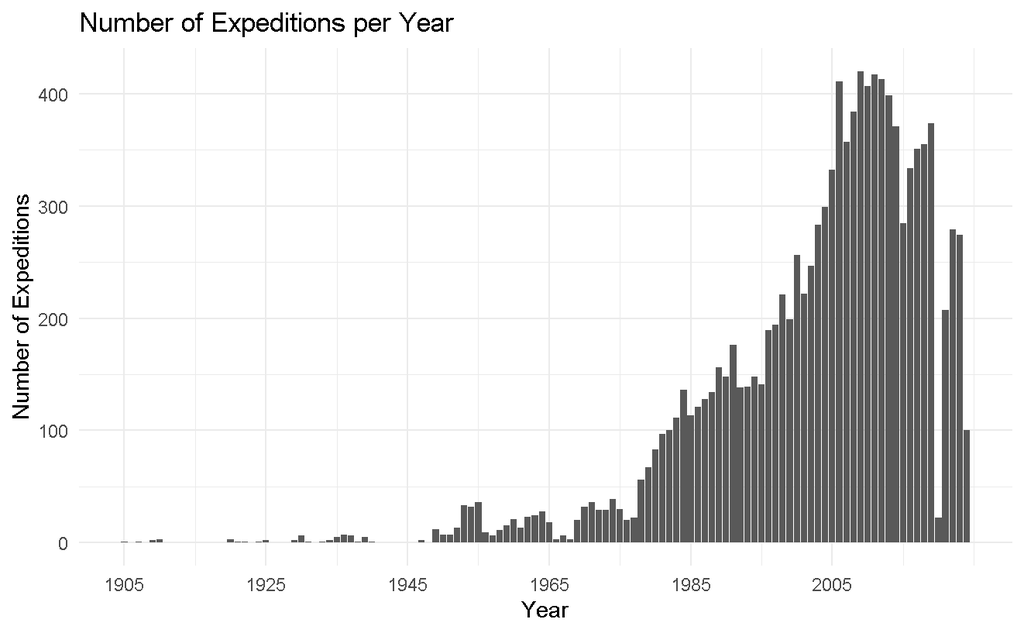

```r
ggplot(exped_temp, aes(x = as.numeric(YEAR))) +
  geom_bar() +
  scale_x_continuous(
    breaks = seq(
      from = min(as.numeric(exped_temp$YEAR), na.rm = TRUE),
      to = max(as.numeric(exped_temp$YEAR), na.rm = TRUE),
      by = 20
    )
  ) +
  labs(
    title = "Number of Expeditions per Year",
    x = "Year",
    y = "Number of Expeditions"
  ) +
  theme_minimal()
```

## Data Cleaning and Preprocessing

The dataset we will use at the end of the data cleaning and preprocessing is a **merged version** of the peaks_tidy and exped_tidy datasets, filtered to include only expeditions from the year 2000 onwards. The main steps of cleaning included:

- A detailed **description of available features**, distinguishing between numeric, categorical, and logical variables.
- Handling of missing values:
  - **Features with more than 40% missing values were discarded**.
  - For the remaining ones, missing values are being addressed through appropriate **data imputation techniques** (to be finalized, e.g., median/mode for numerical/categorical, or domain-specific strategies).

  Planned additions:
  - Identify and address duplicate entries.
  - Standardize categorical levels (e.g., for country names, reasons for termination, etc.).

PEAK_TIDY DATASET DESCRIPTION

[output not shown]

EXPED_TIDY DATASET DESCRIPTION

[output not shown]

### Handling NaN

At he moment the data contain a lot of NaN, I want to check If exist some columns that are principaly composed of missing values, if exists, we will remove them

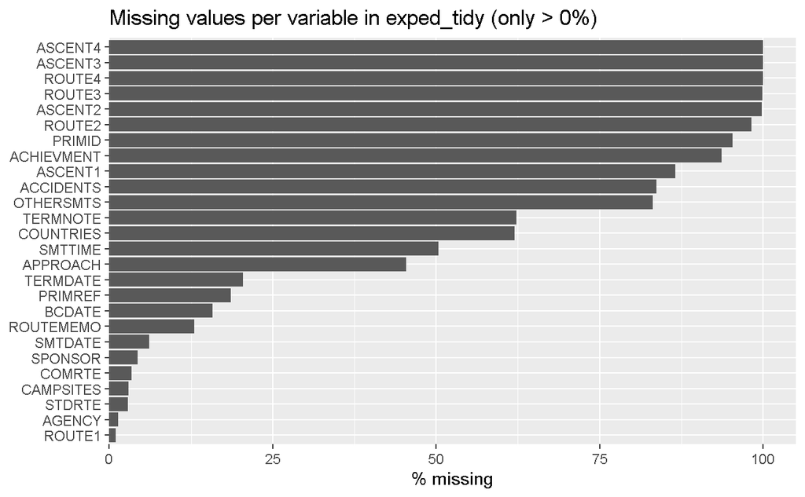

```r
# 1. Compute % missing per column
miss_pct <- exped_tidy %>%
  summarise_all(~ mean(is.na(.)) * 100) %>%
  pivot_longer(everything(), names_to = "variable", values_to = "pct_missing")

# 2. Filter for columns with > 0% missing values
miss_pct_filtered <- miss_pct %>%
  filter(pct_missing > 0)

# 3. Plot
miss_pct_filtered %>%
  ggplot(aes(x = pct_missing, y = fct_reorder(variable, pct_missing))) +
  geom_col() +
  labs(
    x = "% missing",
    y = NULL,
    title = "Missing values per variable in exped_tidy (only > 0%)"
  ) +
  scale_x_continuous(expand = expansion(mult = c(0, .05)))
```

```r
missing_pct <- round(colSums(is.na(exped_tidy)) / nrow(exped_tidy) * 100, 2)
missing_df <- data.frame(Column = names(missing_pct), MissingPercentage = missing_pct)

# Create a color-scaled table
formattable(
  missing_df[order(-missing_df$MissingPercentage), ],
  list(
    MissingPercentage = color_tile("white", "red")
  )
)
```

|  | Column | MissingPercentage |
| --- | --- | --- |
| ASCENT3 | ASCENT3 | 100.00 |
| ASCENT4 | ASCENT4 | 100.00 |
| ROUTE4 | ROUTE4 | 99.99 |
| ROUTE3 | ROUTE3 | 99.87 |
| ASCENT2 | ASCENT2 | 99.77 |
| ROUTE2 | ROUTE2 | 98.17 |
| PRIMID | PRIMID | 95.32 |
| ACHIEVMENT | ACHIEVMENT | 93.69 |
| ASCENT1 | ASCENT1 | 86.54 |
| ACCIDENTS | ACCIDENTS | 83.72 |
| OTHERSMTS | OTHERSMTS | 83.09 |
| TERMNOTE | TERMNOTE | 62.30 |
| COUNTRIES | COUNTRIES | 61.97 |
| SMTTIME | SMTTIME | 50.39 |
| APPROACH | APPROACH | 45.40 |
| TERMDATE | TERMDATE | 20.45 |
| PRIMREF | PRIMREF | 18.57 |
| BCDATE | BCDATE | 15.82 |
| ROUTEMEMO | ROUTEMEMO | 12.98 |
| SMTDATE | SMTDATE | 6.08 |
| SPONSOR | SPONSOR | 4.39 |
| COMRTE | COMRTE | 3.46 |
| CAMPSITES | CAMPSITES | 2.95 |
| STDRTE | STDRTE | 2.82 |
| AGENCY | AGENCY | 1.38 |
| ROUTE1 | ROUTE1 | 1.01 |
| EXPID | EXPID | 0.00 |
| PEAKID | PEAKID | 0.00 |
| YEAR | YEAR | 0.00 |
| SEASON | SEASON | 0.00 |
| SEASON_FACTOR | SEASON_FACTOR | 0.00 |
| HOST | HOST | 0.00 |
| HOST_FACTOR | HOST_FACTOR | 0.00 |
| NATION | NATION | 0.00 |
| LEADERS | LEADERS | 0.00 |
| SUCCESS1 | SUCCESS1 | 0.00 |
| SUCCESS2 | SUCCESS2 | 0.00 |
| SUCCESS3 | SUCCESS3 | 0.00 |
| SUCCESS4 | SUCCESS4 | 0.00 |
| CLAIMED | CLAIMED | 0.00 |
| DISPUTED | DISPUTED | 0.00 |
| SMTDAYS | SMTDAYS | 0.00 |
| TOTDAYS | TOTDAYS | 0.00 |
| TERMREASON | TERMREASON | 0.00 |
| TERMREASON_FACTOR | TERMREASON_FACTOR | 0.00 |
| HIGHPOINT | HIGHPOINT | 0.00 |
| TRAVERSE | TRAVERSE | 0.00 |
| SKI | SKI | 0.00 |
| PARAPENTE | PARAPENTE | 0.00 |
| CAMPS | CAMPS | 0.00 |
| ROPE | ROPE | 0.00 |
| TOTMEMBERS | TOTMEMBERS | 0.00 |
| SMTMEMBERS | SMTMEMBERS | 0.00 |
| MDEATHS | MDEATHS | 0.00 |
| TOTHIRED | TOTHIRED | 0.00 |
| SMTHIRED | SMTHIRED | 0.00 |
| HDEATHS | HDEATHS | 0.00 |
| NOHIRED | NOHIRED | 0.00 |
| O2USED | O2USED | 0.00 |
| O2NONE | O2NONE | 0.00 |
| O2CLIMB | O2CLIMB | 0.00 |
| O2DESCENT | O2DESCENT | 0.00 |
| O2SLEEP | O2SLEEP | 0.00 |
| O2MEDICAL | O2MEDICAL | 0.00 |
| O2TAKEN | O2TAKEN | 0.00 |
| O2UNKWN | O2UNKWN | 0.00 |
| PRIMRTE | PRIMRTE | 0.00 |
| PRIMMEM | PRIMMEM | 0.00 |
| CHKSUM | CHKSUM | 0.00 |

Now we are doing the same for the dataset peaks_tidy

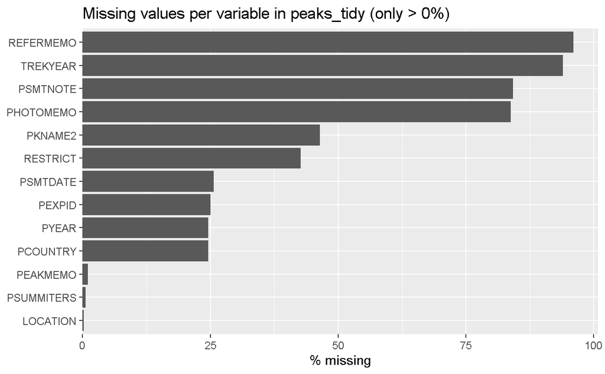

```r
# 1. Compute % missing per column
miss_pct <- peaks_tidy %>%
  summarise_all(~ mean(is.na(.)) * 100) %>%
  pivot_longer(everything(), names_to = "variable", values_to = "pct_missing")

# 2. Filter for columns with > 0% missing values
miss_pct_filtered <- miss_pct %>%
  filter(pct_missing > 0)

# 3. Plot
miss_pct_filtered %>%
  ggplot(aes(x = pct_missing, y = fct_reorder(variable, pct_missing))) +
  geom_col() +
  labs(
    x = "% missing",
    y = NULL,
    title = "Missing values per variable in peaks_tidy (only > 0%)"
  ) +
  scale_x_continuous(expand = expansion(mult = c(0, .05)))
```

```r
missing_pct <- round(colSums(is.na(peaks_tidy)) / nrow(peaks_tidy) * 100, 2)
missing_df <- data.frame(Column = names(missing_pct), MissingPercentage = missing_pct)

# Create a color-scaled table
formattable(
  missing_df[order(-missing_df$MissingPercentage), ],
  list(
    MissingPercentage = color_tile("white", "red")
  )
)
```

|  | Column | MissingPercentage |
| --- | --- | --- |
| REFERMEMO | REFERMEMO | 96.04 |
| TREKYEAR | TREKYEAR | 93.96 |
| PSMTNOTE | PSMTNOTE | 84.17 |
| PHOTOMEMO | PHOTOMEMO | 83.75 |
| PKNAME2 | PKNAME2 | 46.46 |
| RESTRICT | RESTRICT | 42.71 |
| PSMTDATE | PSMTDATE | 25.62 |
| PEXPID | PEXPID | 25.00 |
| PYEAR | PYEAR | 24.58 |
| PCOUNTRY | PCOUNTRY | 24.58 |
| PEAKMEMO | PEAKMEMO | 1.04 |
| PSUMMITERS | PSUMMITERS | 0.62 |
| LOCATION | LOCATION | 0.21 |
| PEAKID | PEAKID | 0.00 |
| PKNAME | PKNAME | 0.00 |
| HEIGHTM | HEIGHTM | 0.00 |
| HEIGHTF | HEIGHTF | 0.00 |
| HIMAL | HIMAL | 0.00 |
| HIMAL_FACTOR | HIMAL_FACTOR | 0.00 |
| REGION | REGION | 0.00 |
| REGION_FACTOR | REGION_FACTOR | 0.00 |
| OPEN | OPEN | 0.00 |
| UNLISTED | UNLISTED | 0.00 |
| TREKKING | TREKKING | 0.00 |
| PHOST | PHOST | 0.00 |
| PHOST_FACTOR | PHOST_FACTOR | 0.00 |
| PSTATUS | PSTATUS | 0.00 |
| PSTATUS_FACTOR | PSTATUS_FACTOR | 0.00 |
| PSEASON | PSEASON | 0.00 |

#### Very High NA% (over 40%)

These columns have extremely high missing rates and are usually not useful unless they’re absolutely critical:

We decided to drop all this columns because of the first analysis of the NaN values

```r
cols_to_drop_exped <- c(
  "ASCENT3", "ASCENT4", "ROUTE4", "ROUTE3", "ASCENT2", "ROUTE2", "PRIMID", "ACHIEVMENT",
  "ASCENT1", "OTHERSMTS", "TERMNOTE", "COUNTRIES", "SMTTIME", "APPROACH"
)

exped_tidy <- exped_tidy |> dplyr::select(-all_of(cols_to_drop_exped))

cols_to_drop_peaks <- c(
  "REFERMEMO", "TREKYEAR", "PSMTNOTE", "PHOTOMEMO", "PKNAME2", "RESTRICT"
)

peaks_tidy <- peaks_tidy |> dplyr::select(-all_of(cols_to_drop_peaks))
```

### Handling features that aren’t informative

After handling columns with excessive missing values, we proceed to remove additional variables that are not informative for modeling or analysis.

These columns fall into one or more of the following categories: -

- Descriptive text fields (e.g., notes, comments, or memos) that are unique and not analytically useful
- Redundant variables where a clearer human-readable factor version already exists
- High-cardinality identifiers (e.g., names or sponsors) that are not relevant to our research questions

This step is crucial to reduce noise, avoid overfitting in machine learning models, and simplify our dataset for exploration and modeling.

```r
# Count unique values per column
unique_counts <- sapply(exped_tidy, function(x) length(unique(x)))

# Sort descending
sort(unique_counts, decreasing = TRUE)
```

```
            EXPID         CAMPSITES         ROUTEMEMO           SPONSOR           LEADERS            CHKSUM            BCDATE           SMTDATE          TERMDATE
             7799              7187              6788              6546              4188              3679              2427              2262              2101
        ACCIDENTS            AGENCY         HIGHPOINT            ROUTE1            PEAKID              ROPE            NATION           TOTDAYS           SMTDAYS
             1216               859               556               555               331               124                92                84                71
         TOTHIRED        TOTMEMBERS          SMTHIRED        SMTMEMBERS              YEAR        TERMREASON TERMREASON_FACTOR             CAMPS           MDEATHS
               54                43                38                34                25                14                14                12                 7
          HDEATHS            SEASON     SEASON_FACTOR              HOST       HOST_FACTOR            COMRTE            STDRTE           PRIMREF          SUCCESS1
                7                 4                 4                 4                 4                 3                 3                 3                 2
         SUCCESS2          SUCCESS3          SUCCESS4           CLAIMED          DISPUTED          TRAVERSE               SKI         PARAPENTE           NOHIRED
                2                 2                 2                 2                 2                 2                 2                 2                 2
           O2USED            O2NONE           O2CLIMB         O2DESCENT           O2SLEEP         O2MEDICAL           O2TAKEN           O2UNKWN           PRIMRTE
                2                 2                 2                 2                 2                 2                 2                 2                 2
          PRIMMEM
                2
```

```r
columns_to_drop_peaks <- c(
  "PKNAME2", "HEIGHTF", "HIMAL_FACTOR", "REGION_FACTOR", "OPEN",
  "UNLISTED", "TREKKING", "TREKYEAR", "RESTRICT", "PHOST_FACTOR",
  "PSTATUS_FACTOR", "PEAKMEMO", "PYEAR", "PSEASON", "PEXPID",
  "PSMTDATE", "PCOUNTRY", "PSUMMITERS", "PSMTNOTE", "REFERMEMO",
  "PHOTOMEMO"
)

columns_to_drop_exped <- c(
  "SPONSOR", "ASCENT1", "ASCENT2", "ASCENT3", "ASCENT4", "APPROACH", "TERMREASON_FACTOR", "TERMNOTE", "SKI", "PARAPENTE", "O2NONE","CAMPSITES", "ROUTEMEMO","ACHIEVMENT", "PRIMRTE", "PRIMMEM", "PRIMREF", "PRIMID", "CHKSUM", "ACCIDENTS", "AGENCY", "OTHERSMTS", "LEADERS", "NATION", "COUNTRIES"
)

peaks_tidy <- peaks_tidy |> select(-any_of(columns_to_drop_peaks))

exped_tidy <- exped_tidy |> select(-any_of(c(columns_to_drop_exped)))
```

### Missing values imputation

To ensure our dataset is complete and ready for modeling, we apply appropriate missing value imputation.

This step ensures that we do not lose rows due to NAs during model fitting.

```r
# Imputation - exped_tidy
numeric_vars_exped <- names(exped_tidy)[sapply(exped_tidy, is.numeric)]
exped_numeric <- exped_tidy[, numeric_vars_exped]

# KNN Imputation for numeric vars
exped_numeric_imputed <- kNN(exped_numeric, k = 5, imp_var = FALSE)
```

```
G2;H2;Warningh in kNN(exped_numeric, k = 5, imp_var = FALSE) :
  Nothing to impute, because no NA are present (also after using makeNA)g
```

```r
exped_tidy[numeric_vars_exped] <- exped_numeric_imputed

# Categorical
cat_vars_exped <- names(exped_tidy)[sapply(exped_tidy, function(x) is.character(x) || is.factor(x))]
for (col in cat_vars_exped) {
  exped_tidy[[col]] <- as.character(exped_tidy[[col]])
  exped_tidy[[col]][is.na(exped_tidy[[col]])] <- "Missing"
  exped_tidy[[col]] <- as.factor(exped_tidy[[col]])
}

# Logical
log_vars_exped <- names(exped_tidy)[sapply(exped_tidy, is.logical)]
for (col in log_vars_exped) {
  exped_tidy[[col]][is.na(exped_tidy[[col]])] <- FALSE
}
```

```r
# Imputation - peaks_tidy
numeric_vars_peaks <- names(peaks_tidy)[sapply(peaks_tidy, is.numeric)]
peaks_numeric <- peaks_tidy[, numeric_vars_peaks]

# KNN Imputation
peaks_numeric_imputed <- kNN(peaks_numeric, k = 5, imp_var = FALSE)
```

```
G2;H2;Warningh in kNN(peaks_numeric, k = 5, imp_var = FALSE) :
  Nothing to impute, because no NA are present (also after using makeNA)g
```

```r
peaks_tidy[numeric_vars_peaks] <- peaks_numeric_imputed

# Categorical
cat_vars_peaks <- names(peaks_tidy)[sapply(peaks_tidy, function(x) is.character(x) || is.factor(x))]
for (col in cat_vars_peaks) {
  peaks_tidy[[col]] <- as.character(peaks_tidy[[col]])
  peaks_tidy[[col]][is.na(peaks_tidy[[col]])] <- "Missing"
  peaks_tidy[[col]] <- as.factor(peaks_tidy[[col]])
}

# Logical
log_vars_peaks <- names(peaks_tidy)[sapply(peaks_tidy, is.logical)]
for (col in log_vars_peaks) {
  peaks_tidy[[col]][is.na(peaks_tidy[[col]])] <- FALSE
}
```

```r
sum(is.na(exped_tidy))
```

```
[1] 3303
```

```r
sum(is.na(peaks_tidy))
```

```
[1] 0
```

Every imputation where done correctly, but we have still some missing datas. So let’s explore it again

```r
na_counts <- colSums(is.na(exped_tidy))
na_counts[na_counts > 0]
```

```
  BCDATE  SMTDATE TERMDATE
    1234      474     1595
```

```r
library(lubridate)

exped_tidy <- exped_tidy |> mutate(
  DAYS_TO_END = as.numeric(TERMDATE - BCDATE),
  DAY_OF_YEAR_START = yday(BCDATE)
)
```

```r
exped_tidy <- exped_tidy |> select(-BCDATE, -SMTDATE, -TERMDATE)
```

```r
colSums(is.na(exped_tidy[c("DAYS_TO_END", "DAY_OF_YEAR_START")]))
```

```
      DAYS_TO_END DAY_OF_YEAR_START
             1629              1234
```

```r
# Imputation con KNN se necessario

to_impute <- exped_tidy[, c("DAYS_TO_END", "DAY_OF_YEAR_START")]
to_impute_knn <- kNN(to_impute, k = 5, imp_var = FALSE)
exped_tidy[, c("DAYS_TO_END", "DAY_OF_YEAR_START")] <- to_impute_knn
```

```r
# Now should be both 0
sum(is.na(exped_tidy))
```

```
[1] 0
```

```r
sum(is.na(peaks_tidy))
```

```
[1] 0
```

We transformed date fields into numeric variables to preserve meaningful temporal information while making them usable in modeling. Specifically, we computed:

- `DAYS_TO_END`: days from base camp arrival to expedition termination
- `DAY_OF_YEAR_START`: expedition start day of the year

We removed the original date columns and applied KNN imputation (k = 5) on the derived variables to handle remaining missing values.

### Duplicates

```r
duplicated_rows_exped <- exped_tidy[duplicated(exped_tidy), ]
duplicated_rows_peaks <- peaks_tidy[duplicated(peaks_tidy), ]
nrow(duplicated_rows_exped)
```

```
[1] 0
```

```r
nrow(duplicated_rows_peaks)
```

```
[1] 0
```

### Join the two datasets

```r
exped_full <- exped_tidy |>
  left_join(peaks_tidy, by = "PEAKID")
```

### Encoding

To make our dataset suitable for modeling, we encoded all categorical variables as factors. This allows R’s linear and logistic regression functions (`lm()`, `glm()`) to automatically generate appropriate dummy variables internally.

```r
# Convert character columns to factor
exped_full <- exped_full |> mutate(
  across(where(is.character), as.factor)
)
```

```r
# List categorical variables
cat_vars <- names(exped_full)[sapply(exped_full, is.factor)]
```

### Scaling

We excluded logical and categorical variables from this process.

```r
# Identify right-skewed predictors (excluding HIGHPOINT)
right_skewed_vars <- c(
  "SMTDAYS", "TOTDAYS", "CAMPS", "ROPE",
  "TOTMEMBERS", "SMTMEMBERS", "MDEATHS",
  "TOTHIRED", "SMTHIRED", "HDEATHS"
)

# Apply log1p transformation to selected predictors only
exped_full <- exped_full |>
  mutate(across(all_of(right_skewed_vars), log1p))
```

```r
# Trova le variabili numeriche
numeric_vars <- names(exped_full)[sapply(exped_full, is.numeric)]

# Conta i valori unici
unique_counts <- sapply(exped_full[numeric_vars], function(x) length(unique(x)))

# Mostra le variabili con <= 10 valori unici (sospette categorie)
sort(unique_counts[unique_counts <= 10])
```

```
PSTATUS  SEASON    HOST   PHOST MDEATHS HDEATHS  REGION
      2       4       4       5       7       7       7
```

```r
# Variables to scale (excluding binary and categorical-encoded ones)
numeric_vars <- names(exped_full)[sapply(exped_full, is.numeric)]

# Exclude vars we don't want to scale
to_exclude <- c("SUCCESS1", "O2USED", "O2CLIMB", "O2DESCENT", "O2SLEEP",
                "O2MEDICAL", "O2TAKEN", "O2UNKWN", "NOHIRED",
                "SEASON", "HOST", "TERMREASON", "REGION", "PHOST", "PSTATUS", "HIMAL", "HIGHPOINT", "HEIGHTM")

vars_to_scale <- setdiff(numeric_vars, to_exclude)

# Apply z-score standardization
exped_full[vars_to_scale] <- scale(exped_full[vars_to_scale])
```

## Data Exploration (EDA)

Currently underway:

- Summary statistics and distribution plots for **numerical features**.
- Planned analysis for:
  - **Categorical features** (e.g., country, season, termination reason)
  - **Logical features** (e.g., use of oxygen, success/failure).
- Exploratory visualizations to support modeling choices (e.g., boxplots, bar charts, correlation heatmaps).

Overview of the dataset and the features

```r
sapply(exped_full, class) |> table()
```

```
 factor integer logical numeric
      7       9      17      13
```

```r
sapply(exped_full, class) |> sort()
```

```
            EXPID            PEAKID     SEASON_FACTOR       HOST_FACTOR            ROUTE1            PKNAME          LOCATION            SEASON              HOST
         "factor"          "factor"          "factor"          "factor"          "factor"          "factor"          "factor"         "integer"         "integer"
       TERMREASON         HIGHPOINT           HEIGHTM             HIMAL            REGION             PHOST           PSTATUS          SUCCESS1          SUCCESS2
        "integer"         "integer"         "integer"         "integer"         "integer"         "integer"         "integer"         "logical"         "logical"
         SUCCESS3          SUCCESS4           CLAIMED          DISPUTED          TRAVERSE           NOHIRED            O2USED           O2CLIMB         O2DESCENT
        "logical"         "logical"         "logical"         "logical"         "logical"         "logical"         "logical"         "logical"         "logical"
          O2SLEEP         O2MEDICAL           O2TAKEN           O2UNKWN            COMRTE            STDRTE              YEAR           SMTDAYS           TOTDAYS
        "logical"         "logical"         "logical"         "logical"         "logical"         "logical"         "numeric"         "numeric"         "numeric"
            CAMPS              ROPE        TOTMEMBERS        SMTMEMBERS           MDEATHS          TOTHIRED          SMTHIRED           HDEATHS       DAYS_TO_END
        "numeric"         "numeric"         "numeric"         "numeric"         "numeric"         "numeric"         "numeric"         "numeric"         "numeric"
DAY_OF_YEAR_START
        "numeric"
```

Analysis of the numerical features:

```r
numeric_vars <- names(exped_full)[sapply(exped_full, is.numeric)]
print(numeric_vars)
```

```
 [1] "YEAR"              "SEASON"            "HOST"              "SMTDAYS"           "TOTDAYS"           "TERMREASON"        "HIGHPOINT"
 [8] "CAMPS"             "ROPE"              "TOTMEMBERS"        "SMTMEMBERS"        "MDEATHS"           "TOTHIRED"          "SMTHIRED"
[15] "HDEATHS"           "DAYS_TO_END"       "DAY_OF_YEAR_START" "HEIGHTM"           "HIMAL"             "REGION"            "PHOST"
[22] "PSTATUS"
```

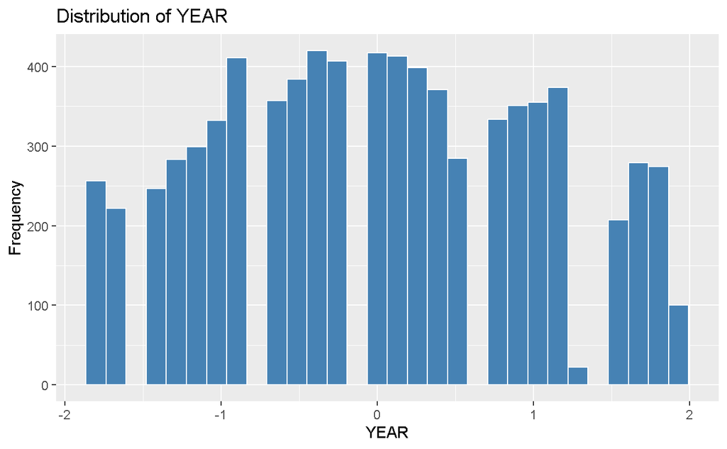

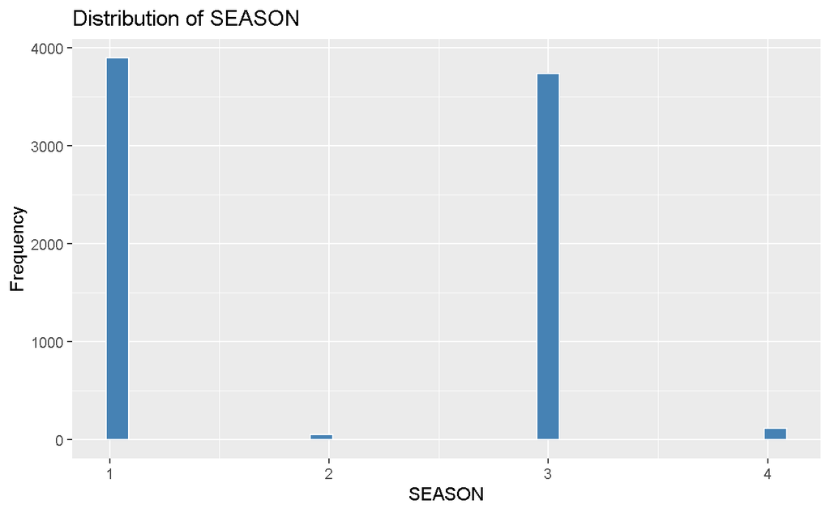

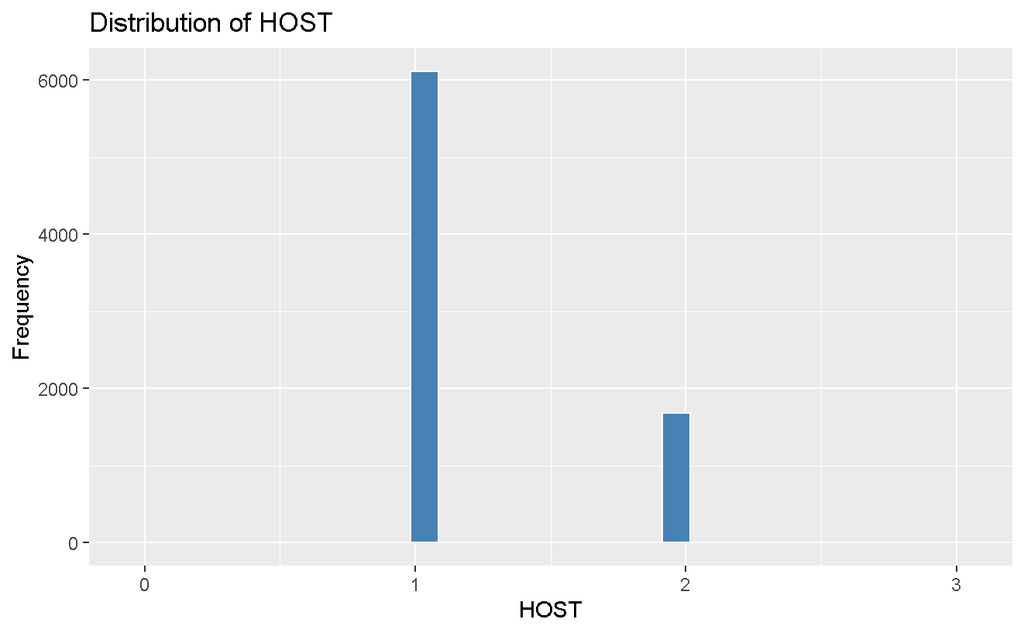

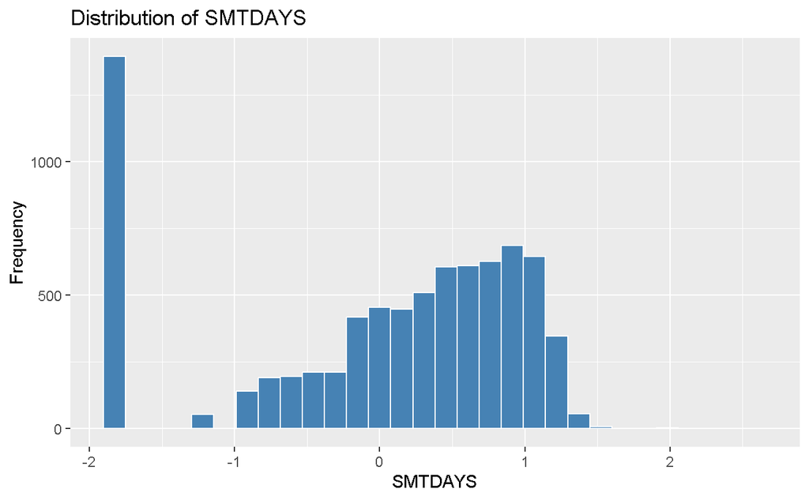

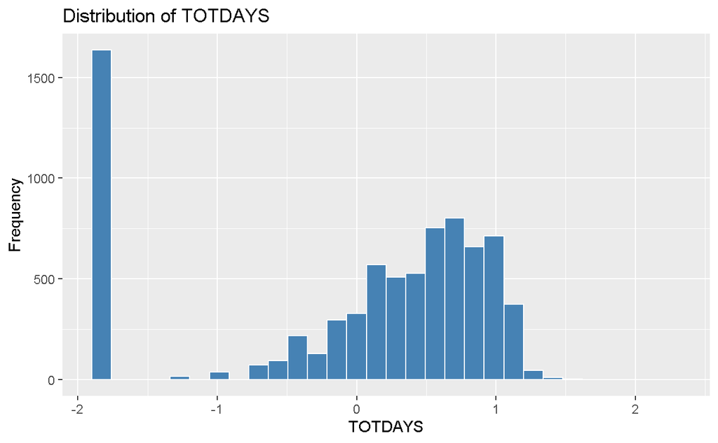

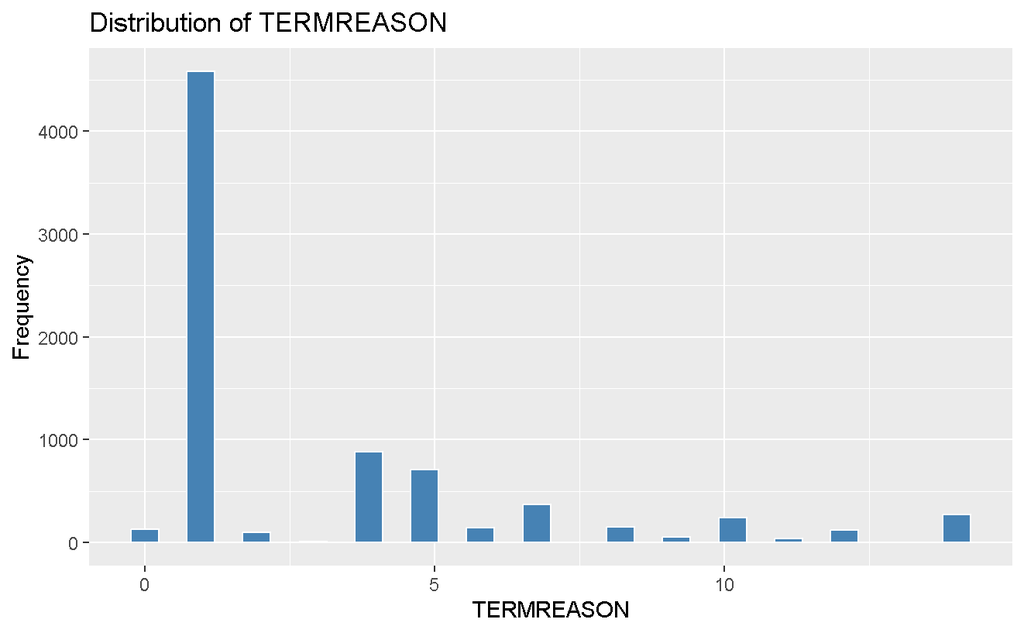

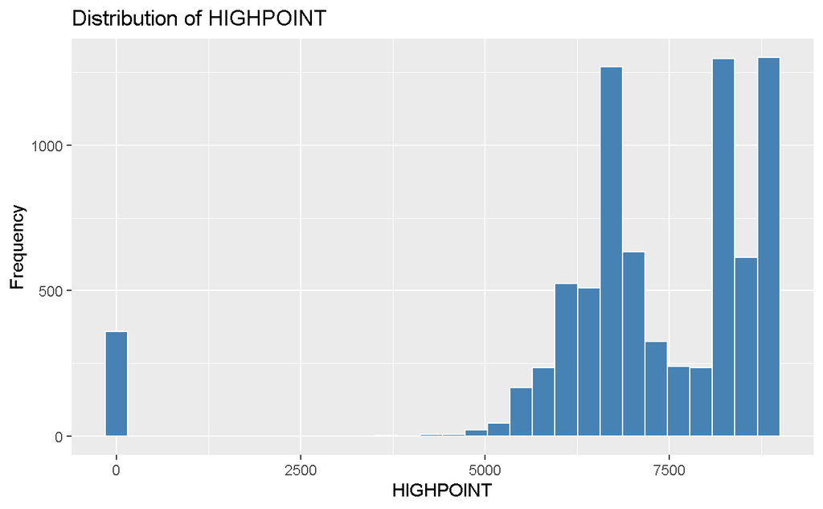

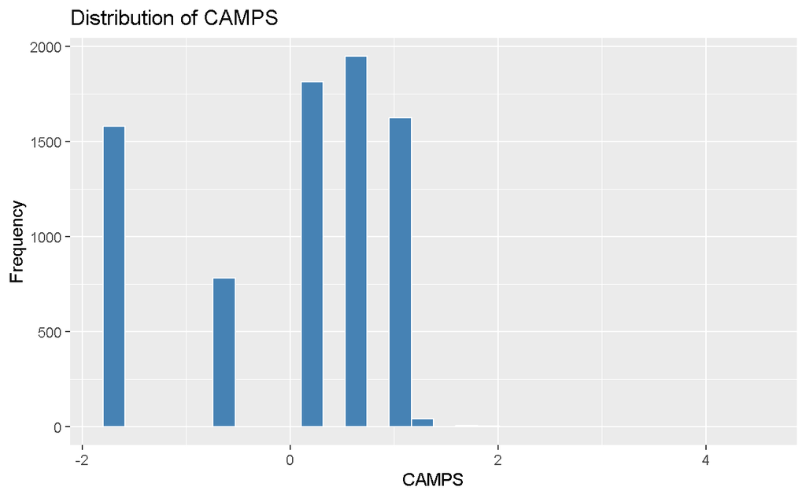

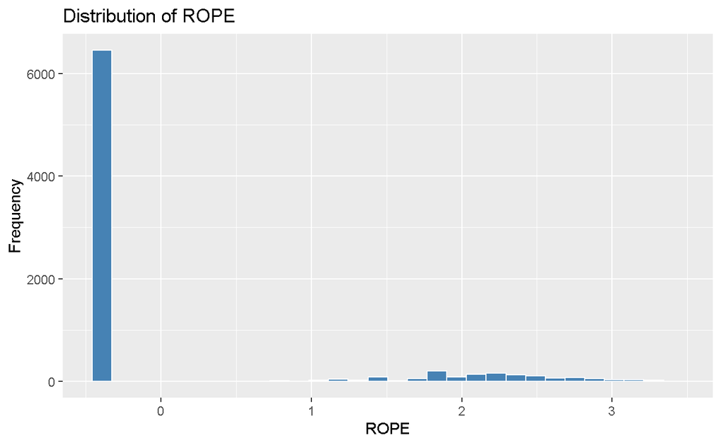

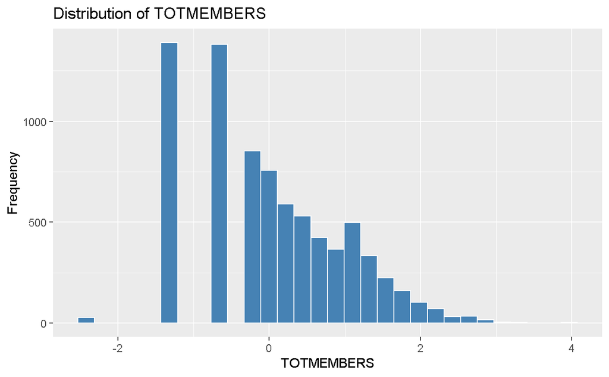

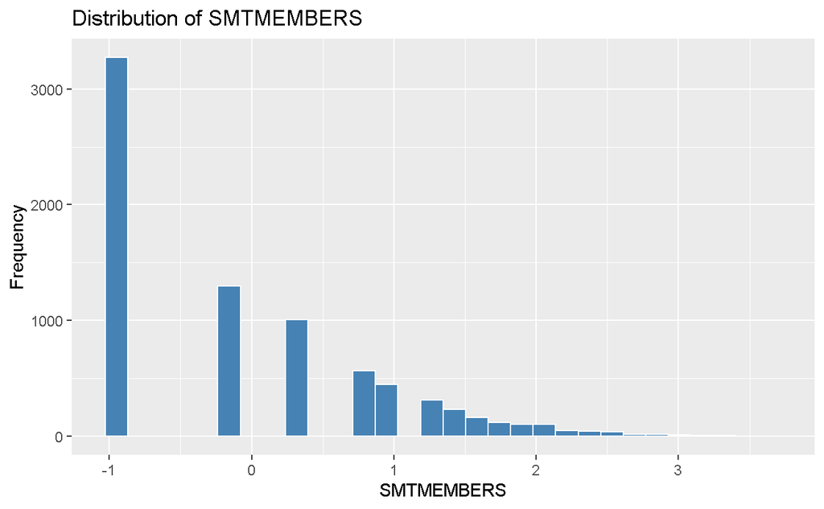

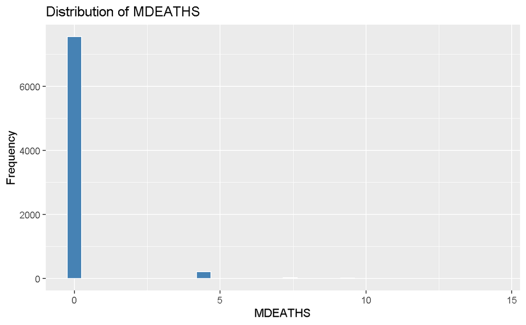

[10 more figures not shown]

```r
for (var in numeric_vars) {
  print(
    ggplot(exped_full, aes(x = .data[[var]])) +
      geom_histogram(bins = 30, fill = "steelblue", color = "white") +
      labs(title = paste("Distribution of", var), x = var, y = "Frequency")
  )
}
```

[figure not shown]

```r
cor_matrix <- exped_full |>
  dplyr::select(all_of(numeric_vars)) |>
  cor(use = "complete.obs")

library(ggcorrplot)
ggcorrplot::ggcorrplot(cor_matrix, lab = TRUE, lab_size = 3)
```

```
G3;Registered S3 method overwritten by 'GGally':
  method from
  +.gg   ggplot2
g
```

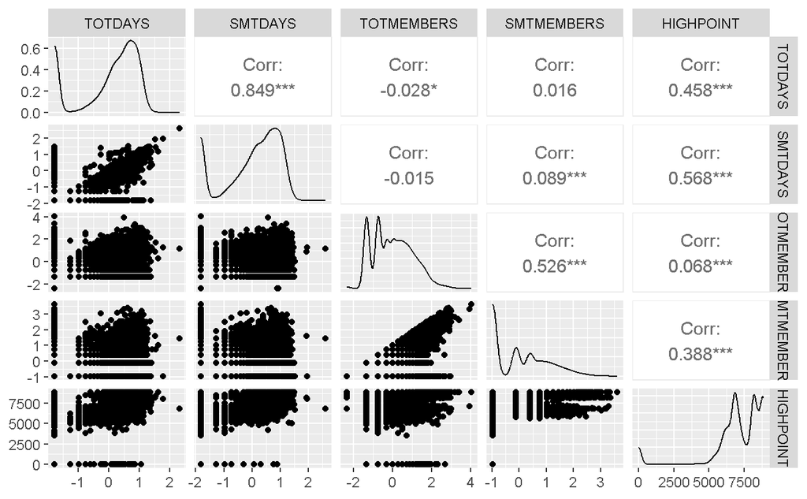

```r
exped_full_num <- exped_full |> select(TOTDAYS, SMTDAYS, TOTMEMBERS, SMTMEMBERS, HIGHPOINT)
GGally::ggpairs(exped_full_num)
```

```r
categorical_vars <- names(exped_full)[sapply(exped_full, function(x) is.character(x) || is.factor(x))]

print(categorical_vars)
```

```
[1] "EXPID"         "PEAKID"        "SEASON_FACTOR" "HOST_FACTOR"   "ROUTE1"        "PKNAME"        "LOCATION"
```

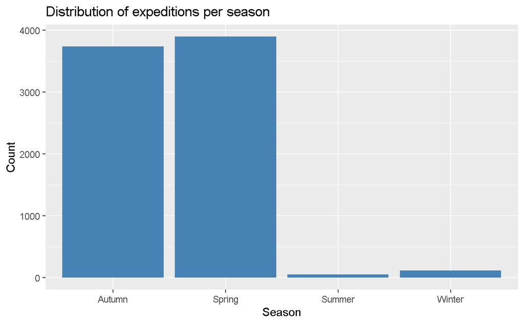

```r
ggplot(exped_full, aes(x = SEASON_FACTOR)) +
  geom_bar(fill = "steelblue") +
  labs(title = "Distribution of expeditions per season", x = "Season", y = "Count")
```

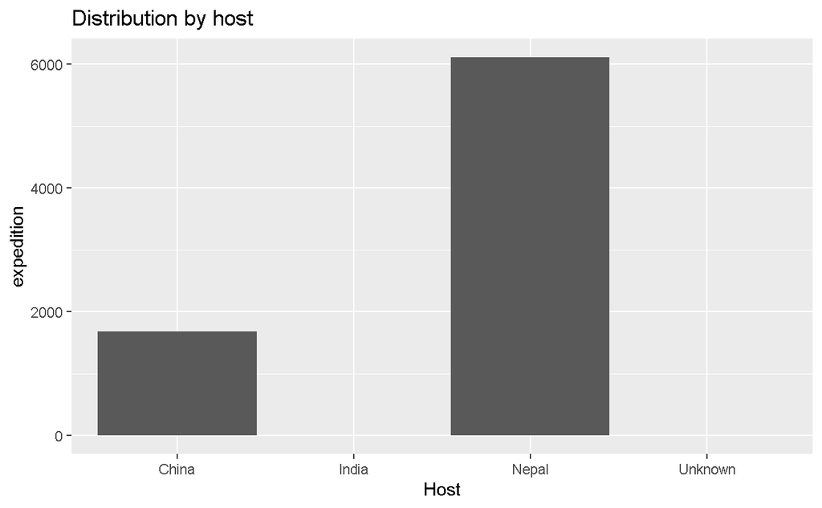

```r
# Distribution by host
exped_full |> count(HOST_FACTOR) |> ggplot(aes(x = HOST_FACTOR, y = n)) +
  geom_bar(stat = "identity") + labs(title = "Distribution by host", x = "Host", y = "expedition")
```

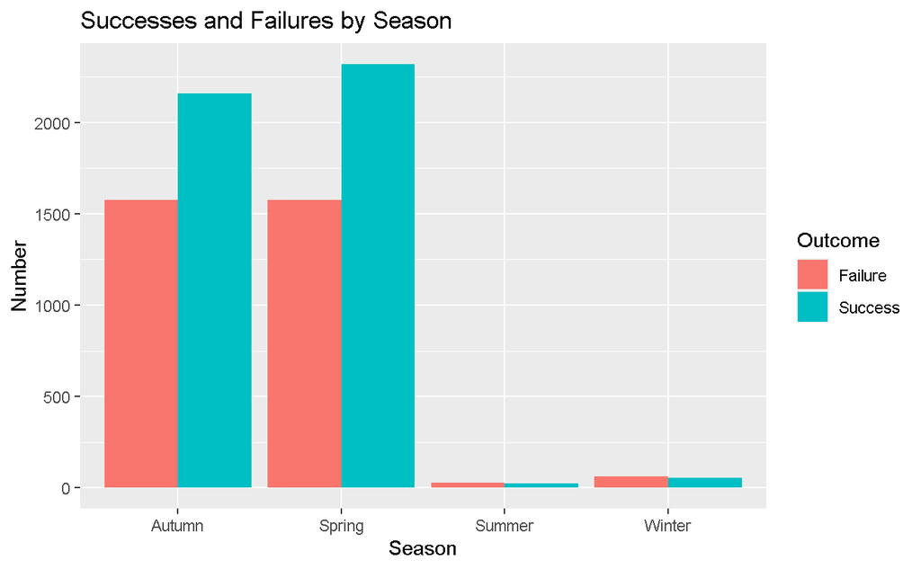

```r
# Success per season
exped_full |>
 mutate(success = ifelse(SUCCESS1, "Success", "Failure")) |>
  count(SEASON_FACTOR, success) |>
 ggplot(aes(x = SEASON_FACTOR, y = n, fill = success)) +
 geom_bar(stat = "identity", position = "dodge") +
 labs(title = "Successes and Failures by Season", x = "Season", y = "Number", fill = "Outcome")
```

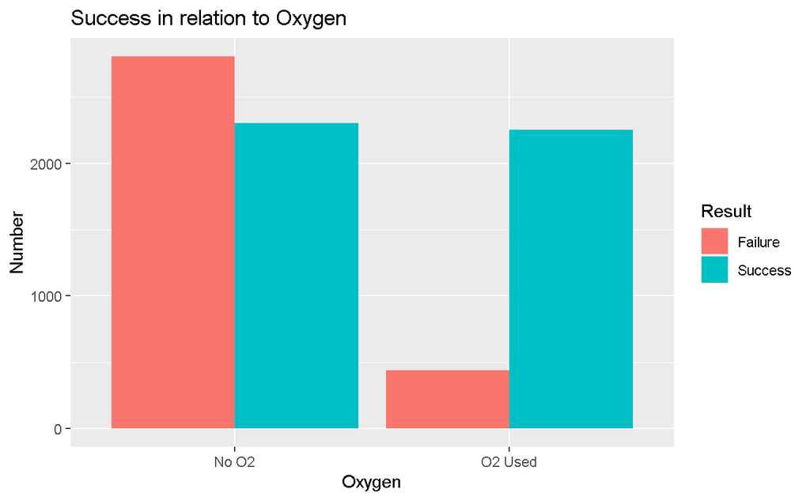

```r
# Oxygen and success
exped_full |>
 mutate(O2_USED = ifelse(O2USED, "O2 Used", "No O2")) |>
 mutate(success = ifelse(SUCCESS1, "Success", "Failure")) |>
  count(O2_USED, success) |>
  ggplot(aes(x = O2_USED, y = n, fill = success)) +
 geom_bar(stat = "identity", position = "dodge") +
 labs(title = "Success in relation to Oxygen", x = "Oxygen", y = "Number", fill = "Result")
```

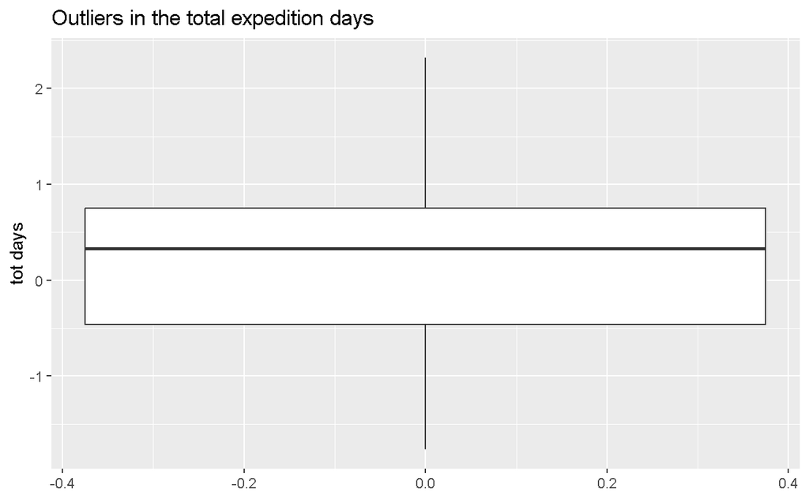

```r
# Boxplot giorni
ggplot(exped_full, aes(y = TOTDAYS)) +
  geom_boxplot() +
  labs(title = "Outliers in the total expedition days", y = "tot days")
```

## Modeling

After conducting a detailed exploratory data analysis on some interesting features of our datasets, we now move to the modeling phase. The goal of this section is to address key questions regarding expedition outcomes using statistical models introduced during the course.

The exploratory phase revealed several factors that may influence expedition success, such as the use of supplementary oxygen, the hosting country, the season, duration, and peak altitude. However, to rigorously assess the impact of each variable, we need to build models that can isolate and quantify these effects.

### Regression

#### 1. Does the use of supplementary oxygen reduce the duration of expeditions?

In this section, we aim to investigate whether the use of supplementary oxygen (`O2USED`) has a measurable effect on the total duration of Himalayan expeditions (`TOTDAYS`). This is a regression problem, as the response variable is continuous.

The variable `O2USED` is binary (`TRUE`/`FALSE`), indicating whether oxygen was used during the expedition. Our working hypothesis is that expeditions using oxygen may have shorter durations, as supplementary oxygen could improve endurance and reduce fatigue at high altitudes.

Understanding this relationship could offer valuable insights into the logistical and physiological implications of oxygen use in high-altitude mountaineering.

We begin with some exploratory visualizations and summary statistics, and then fit a linear regression model to test the association between oxygen use and expedition duration.

```r
exped_full %>%
  group_by(O2USED) %>%
  summarise(
    count = n(),
    mean_days = mean(TOTDAYS),
    sd_days = sd(TOTDAYS),
    median_days = median(TOTDAYS)
  )
```

| O2USED | count | mean_days | sd_days | median_days |
| --- | --- | --- | --- | --- |
| FALSE | 5109 | -0.1771455 | 0.9513781 | 0.1496268 |
| TRUE | 2690 | 0.3364448 | 1.0038654 | 0.7707843 |

We observe that:

- Expeditions **without oxygen** (`O2USED = FALSE`) had a **mean duration** of approximately **-0.18** and a **median** of about **0.15**
- Expeditions **with oxygen** (`O2USED = TRUE`) had a **mean duration** of about **0.34** and a **median** of **0.77**

Now let’s see it in a graphically way:

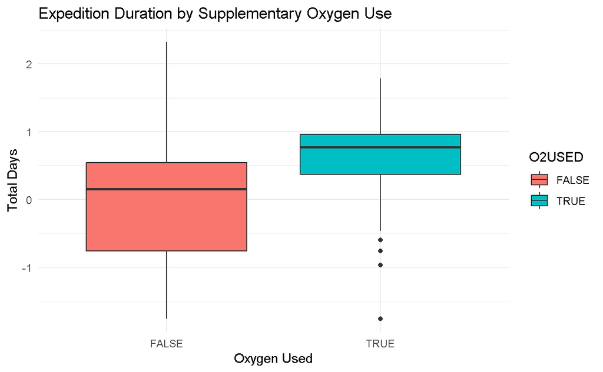

```r
ggplot(exped_full, aes(x = O2USED, y = TOTDAYS, fill = O2USED)) +
  geom_boxplot() +
  labs(title = "Expedition Duration by Supplementary Oxygen Use",
       x = "Oxygen Used",
       y = "Total Days") +
  theme_minimal()
```

The boxplot confirms the trend observed in the summary statistics:

**Expeditions using supplementary oxygen tend to last longer** than those that don’t.

We use a two-sample Welch’s t-test (unequal variance assumed).

```r
t.test(TOTDAYS ~ O2USED, data = exped_full, var.equal = FALSE)
```

```
    Welch Two Sample t-test

data:  TOTDAYS by O2USED
t = -21.864, df = 5219.2, p-value < 2.2e-16
alternative hypothesis: true difference in means between group FALSE and group TRUE is not equal to 0
95 percent confidence interval:
 -0.5596409 -0.4675397
sample estimates:
mean in group FALSE  mean in group TRUE
         -0.1771455           0.3364448
```

We performed a Welch two-sample t-test to compare the average expedition duration between groups using and not using supplementary oxygen.

- The test yields a **highly significant result** (p-value < 2.2e-16), with a **95% confidence interval** for the difference in means between **-0.56 and -0.47**.
- This confirms that there is a **statistically significant difference** in average duration between the two groups.

Interestingly, expeditions **using oxygen actually last longer** on average, contradicting the idea that oxygen shortens climbs. This likely reflects that oxygen is more often used on longer, more demanding expeditions.

```r
# Bootstrap difference in means
set.seed(123)
oxygen_infer <- exped_full %>%
  specify(TOTDAYS ~ O2USED) %>%
  generate(reps = 1000, type = "bootstrap") %>%
  calculate(stat = "diff in means", order = c(TRUE, FALSE))

# Confidence interval
get_confidence_interval(oxygen_infer, level = 0.95, type = "percentile")
```

| lower_ci | upper_ci |
| --- | --- |
| 0.4655127 | 0.5597675 |

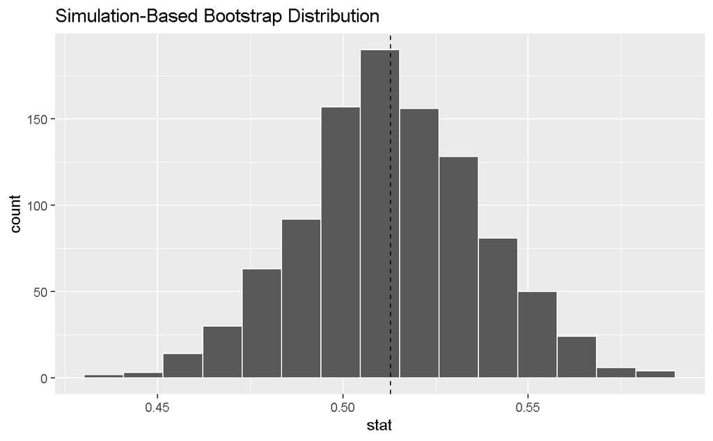

```r
# Plot the bootstrap distribution
visualize(oxygen_infer) +
  geom_vline(xintercept = mean(oxygen_infer$stat), linetype = "dashed")
```

```r
NA
NA
```

To confirm the result from the t-test, we applied a bootstrap approach to estimate the difference in mean expedition duration between the two groups (`O2USED = TRUE` vs `FALSE`).

The simulated bootstrap distribution is centered around **0.50**, reinforcing the finding that expeditions using supplementary oxygen tend to be longer.

This non-parametric method supports the conclusion that the observed difference is not due to random variation.

**Linear Regression**

We model the total expedition duration as:

$$\text{TOTDAYS} = \beta_0 + \beta_1 \cdot \text{O2USED}$$

Where:

- $\beta_0$ is the **mean duration** of expeditions **without supplementary oxygen** (`O2USED = FALSE`)
- $\beta_1$ is the **average difference in duration** between expeditions that **used oxygen** and those that did not

We model the total duration of expeditions (`TOTDAYS`) as a function of oxygen use (`O2USED`), using simple linear regression.

This model helps quantify the expected change in duration when oxygen is used, holding all else constant. Since oxygen use is binary, the coefficient represents the average difference in days between the two groups.

```r
# Fit linear regression
lm_oxy <- lm(TOTDAYS ~ O2USED, data = exped_full)

# Summary of model
summary(lm_oxy)
```

```
Call:
lm(formula = TOTDAYS ~ O2USED, data = exped_full)

Residuals:
    Min      1Q  Median      3Q     Max
-2.0986 -0.2870  0.3767  0.6750  2.4995

Coefficients:
            Estimate Std. Error t value Pr(>|t|)
(Intercept) -0.17715    0.01357  -13.06   <2e-16 ***
O2USEDTRUE   0.51359    0.02310   22.23   <2e-16 ***
---
Signif. codes:  0 '***' 0.001 '**' 0.01 '*' 0.05 '.' 0.1 ' ' 1

Residual standard error: 0.9698 on 7797 degrees of freedom
Multiple R-squared:  0.05961,   Adjusted R-squared:  0.05949
F-statistic: 494.2 on 1 and 7797 DF,  p-value: < 2.2e-16
```

Residuals diagnostics

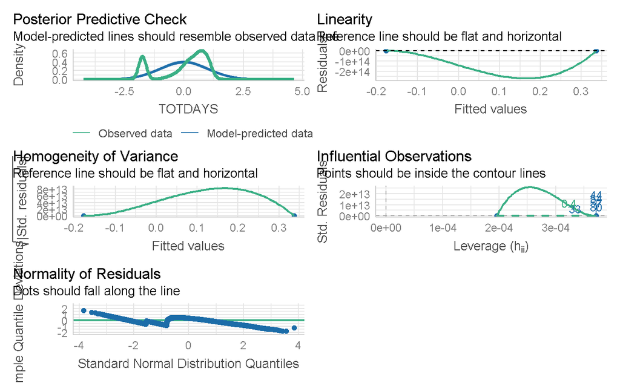

```r
# Residual plots
library(performance)
check_model(lm_oxy)
```

```r
exped_full %>%
  mutate(pred = predict(lm_oxy, newdata = exped_full)) %>%
  metrics(truth = TOTDAYS, estimate = pred)
```

| .metric | .estimator | .estimate |
| --- | --- | --- |
| rmse | standard | 0.96967628 |
| rsq | standard | 0.05960733 |
| mae | standard | 0.78642724 |

The linear regression confirms that expeditions using supplementary oxygen are, on average, **0.51 standard units longer** than those that do not—holding all else constant. This effect is statistically significant (*p* < 0.001).

However, the model’s R² is **very low (~0.06)**, meaning oxygen use alone explains only a small portion of the variation in expedition duration. This suggests that many other factors likely influence duration, which this simple model does not capture, for this reason, a simple linear regression is not sufficient to capture the complexity behind the duration of a successful expedition.

The residual plots show some deviation from ideal assumptions, especially regarding homoscedasticity and normality. Despite this, the model is still useful as an initial approximation of the association.

#### 2. Which features help expeditions reach the summit?

In this section, we aim to understand which factors are most strongly associated with the performance of mountaineering expeditions, measured by the highest point reached (`HIGHPOINT`). This is a regression task with a continuous response variable.

Unlike the previous question, here we include multiple predictors to account for the complexity of an expedition. These include:

- Team size (`TOTMEMBERS`, `SMTMEMBERS`)
- Hired staff (`TOTHIRED`, `SMTHIRED`)
- Use of supplementary oxygen (`O2USED`, `O2CLIMB`)
- Climbing season (`SEASON`)
- Hosting country (`HOST`)
- Logistic factors such as camps, ropes, and support metrics (`CAMPS`, `ROPE`, `COMRTE`, `STDRTE`)

```r
# Filter only complete cases for modeling
model_data <- exped_full %>%
  select(HIGHPOINT, O2USED, TOTMEMBERS, SMTMEMBERS, TOTHIRED, SMTHIRED, O2CLIMB,
         SEASON, HOST, CAMPS, ROPE, COMRTE, STDRTE, HOST_FACTOR) %>%
  drop_na()
```

```r
summary(model_data$HIGHPOINT)
```

```
   Min. 1st Qu.  Median    Mean 3rd Qu.    Max.
      0    6600    7246    7138    8300    8850
```

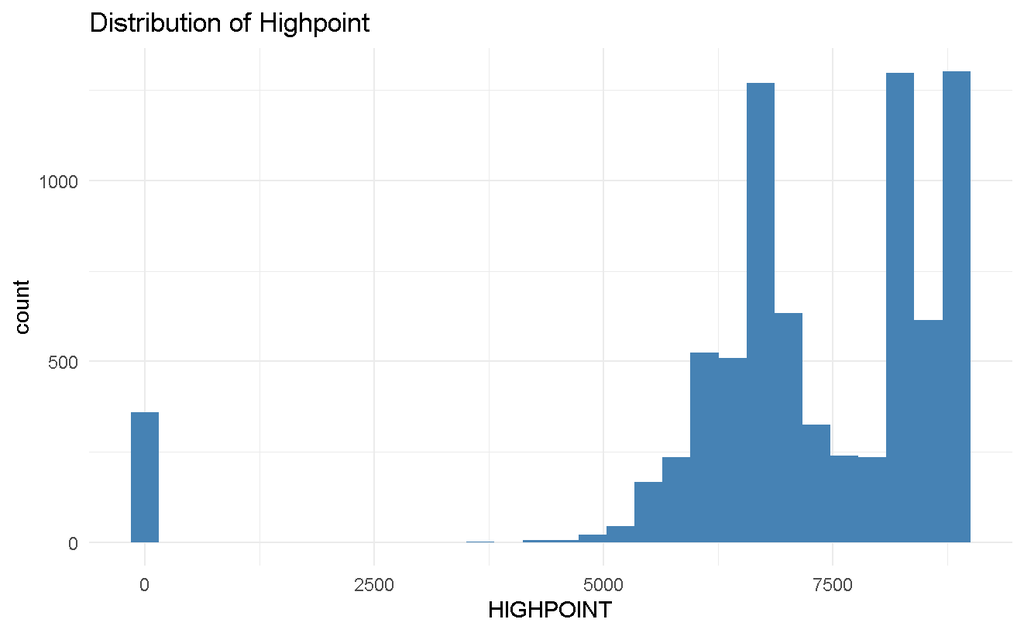

```r
ggplot(model_data, aes(x = HIGHPOINT)) +
  geom_histogram(bins = 30, fill = "steelblue") +
  labs(title = "Distribution of Highpoint") +
  theme_minimal()
```

### Exploring the Target Variable

**Does oxygen use affect highpoint?**

To assess whether the use of supplementary oxygen has a significant effect on expedition performance, we tested for a difference in `HIGHPOINT` between groups that used oxygen and those that did not.

- **Null hypothesis (H₀)**: The mean HIGHPOINT is the same across groups.
- **Alternative hypothesis (H₁)**: The mean HIGHPOINT differs between groups.

We used a **Welch two-sample t-test**, allowing for unequal variances. The test provides statistical evidence on whether the use of oxygen is associated with higher or lower summit outcomes.

```r
t.test(HIGHPOINT ~ O2USED, data = model_data)
```

```
    Welch Two Sample t-test

data:  HIGHPOINT by O2USED
t = -70.108, df = 6308.7, p-value < 2.2e-16
alternative hypothesis: true difference in means between group FALSE and group TRUE is not equal to 0
95 percent confidence interval:
 -2083.220 -1969.888
sample estimates:
mean in group FALSE  mean in group TRUE
           6439.173            8465.727
```

- **Result**: The difference is highly significant (*p* < 2.2e-16).
- Expeditions that used oxygen reached a **much higher average altitude**  
  (mean = **8465.73 m**)  
  compared to those that did not (mean = **6439.17 m**).
- The 95% confidence interval for the difference in means is approximately **[1969.9, 2083.2] meters**

This suggests that oxygen use is **strongly associated with better expedition performance**, likely due to its physiological benefits at extreme altitudes.

```r
aov_result <- aov(HIGHPOINT ~ SEASON, data = model_data)
summary(aov_result)
```

```
              Df    Sum Sq   Mean Sq F value Pr(>F)
SEASON         1 1.700e+09 1.700e+09   518.9 <2e-16 ***
Residuals   7797 2.555e+10 3.276e+06
---
Signif. codes:  0 '***' 0.001 '**' 0.01 '*' 0.05 '.' 0.1 ' ' 1
```